# Descriptives

Shannon Dickson

April 12 2023

# Introduction

**Purpose**: Producing some descriptive statistics and visualisations for the thesis.

**Contributions**: Thanks to Professor Peter Lugtig et al. for providing the original dataset.

# Descriptive Tables

## Table 1. Survey Characteristics

Primary Survey Mode

Survey Characteristic

N

Paper drop, N = 178

F2F, N = 523

Mail, N = 1,759

Telephone, N = 374

Web, N = 333

Topic

3,155

Health

164 (92%)

257 (49%)

1,189 (68%)

197 (53%)

77 (23%)

Other

14 (7.9%)

266 (51%)

558 (32%)

177 (47%)

256 (77%)

Unknown

12

Question type

3,161

Demographic

95 (53%)

271 (52%)

613 (35%)

195 (52%)

214 (64%)

Unobservable

69 (39%)

87 (17%)

800 (45%)

96 (26%)

114 (34%)

Observable

14 (7.9%)

159 (31%)

346 (20%)

83 (22%)

5 (1.5%)

Unknown

6

Special population

3,167

Yes

167 (94%)

203 (39%)

1,178 (67%)

276 (74%)

262 (79%)

No

11 (6.2%)

320 (61%)

581 (33%)

98 (26%)

71 (21%)

Saliency of topic

2,738

Yes

164 (96%)

190 (58%)

1,298 (84%)

311 (85%)

113 (34%)

No

6 (3.5%)

140 (42%)

240 (16%)

56 (15%)

220 (66%)

Unknown

8

193

221

7

Incentives given

3,156

No

178 (100%)

396 (76%)

1,397 (80%)

349 (93%)

290 (87%)

Yes

127 (24%)

352 (20%)

25 (6.7%)

42 (13%)

Unknown

10

1

Reminders sent

3,167

Yes

32 (18%)

96 (18%)

1,132 (64%)

58 (16%)

251 (75%)

No

6 (3.4%)

391 (75%)

298 (17%)

215 (57%)

14 (4.2%)

Undetermined

140 (79%)

36 (6.9%)

329 (19%)

101 (27%)

68 (20%)

Sponsored

3,115

Yes

131 (74%)

359 (70%)

1,482 (85%)

309 (90%)

223 (67%)

No

47 (26%)

154 (30%)

267 (15%)

33 (9.6%)

110 (33%)

Unknown

10

10

32

## Table 2. NR and NRB in Groves and Peytcheva (2008) vs New Studies

Table 1: NR and NRB in the current meta-analysis compared to an earlier meta-analysis

| Studies | Nonresponse Rate | Absolute Relative Bias | N |
| --- | --- | --- | --- |
| New studies | 44.00 | 10.25 | 2342 |
| Groves | 36.01 | 8.32 | 959 |

Note:  
Nonresponse rate and absolute relative bias are expressed as a percentage.

## Table 3. NR and NRB by Survey Mode

Table 2: Nonresponse rates and absolute relative bias by survey mode

| Mode | Nonresponse Rate | Absolute Relative Bias | N |
| --- | --- | --- | --- |
| Mail | 41.54 | 8.98 | 1759 |
| F2F | 26.50 | 8.44 | 523 |
| Telephone | 42.57 | 11.14 | 374 |
| Web | 53.74 | 12.67 | 333 |
| Paper drop | 55.23 | 11.13 | 178 |

Note:  
Nonresponse rate and absolute relative bias are expressed as a percentage.

## Table 4. NR and NRB by Country

Table 3: Nonresponse rates and absolute relative bias by country

| Country | Nonresponse Rate | Absolute Relative Bias | N |
| --- | --- | --- | --- |
| USA | 47.30 | 9.23 | 797 |
| Denmark | 50.98 | 13.02 | 226 |
| UK | 53.37 | 11.97 | 196 |
| Finland | 20.00 | 12.65 | 168 |
| Norway | 24.85 | 4.04 | 159 |
| The Netherlands | 58.03 | 9.93 | 120 |
| Switzerland | 26.82 | 10.07 | 115 |
| Netherlands | 39.33 | 6.42 | 83 |
| Sweden | 19.51 | 6.48 | 82 |
| Australia | 47.96 | 11.44 | 79 |
| Germany | 68.59 | 9.39 | 54 |
| Italy | 22.44 | 12.08 | 44 |
| India | 18.04 | 6.22 | 20 |
| Japan | 80.34 | 14.73 | 11 |
| Canada | 67.19 | 34.42 | 9 |

Note:  
Nonresponse rate and absolute relative bias are expressed as a percentage.

## Table 5. NR and NRB by Information Source on Nonrespondents

Table 4: Nonresponse rates and absolute relative bias by source

| Source | Nonresponse Rate | Absolute Relative Bias | N |
| --- | --- | --- | --- |
| Frame | 48.17 | 11.38 | 1648 |
| Follow up | 29.70 | 7.16 | 841 |
| Supplemental | 38.31 | 8.66 | 588 |
| Screener | 44.91 | 8.84 | 168 |
| Intention to respond | 32.81 | 7.06 | 28 |

Note:  
Nonresponse rate and absolute relative bias are expressed as a percentage.

# Descriptive Figure

## Figure 1. Weighted Correlation of NR and NRB

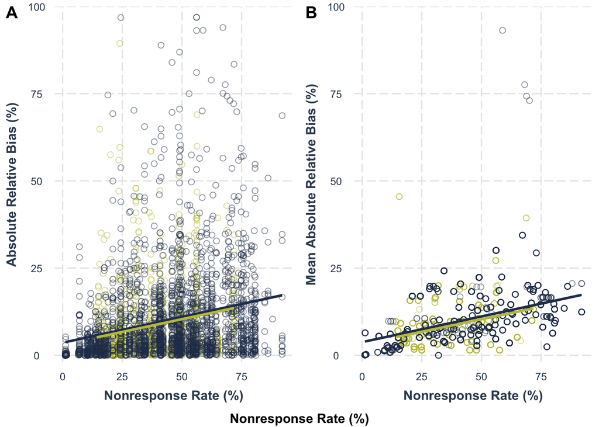

## Figure 1. Yearly Change in NR and NRB

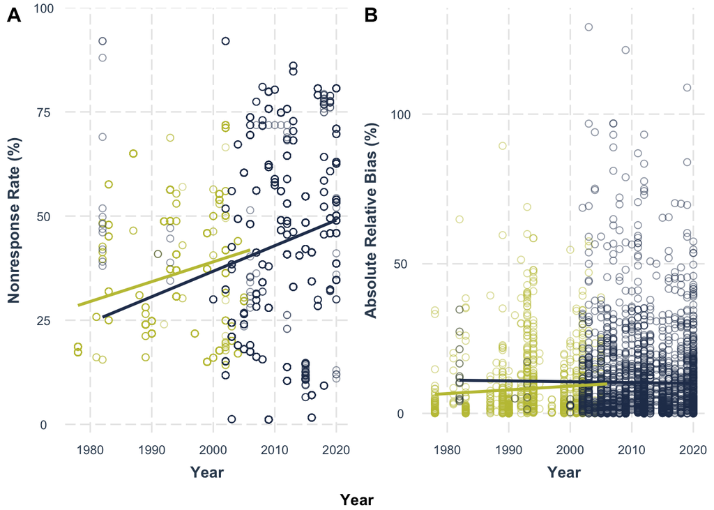

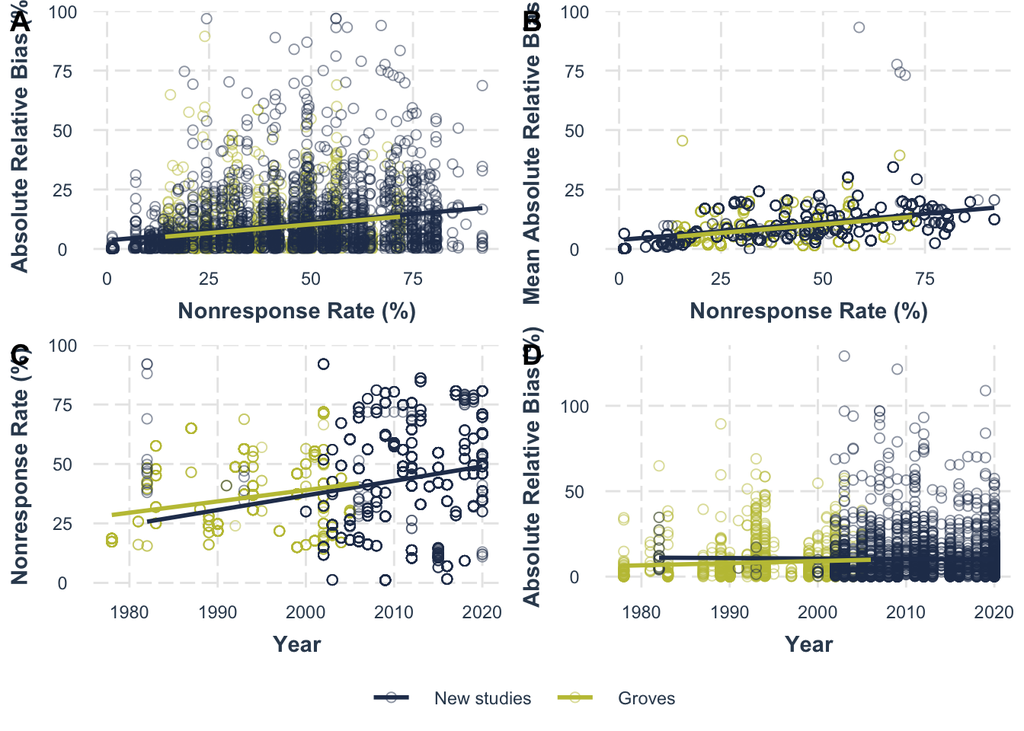

## Figure 2. Distribution of NR and NRB by Survey Mode

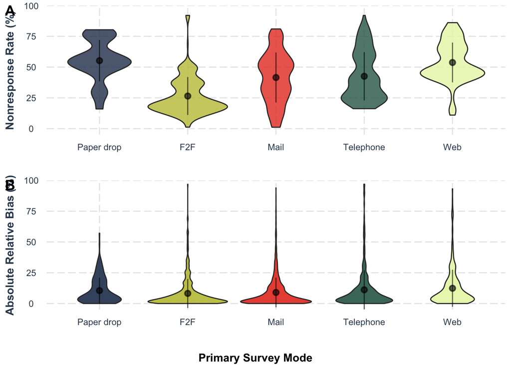